# Coursera Practical Machine Learning Project

Robert C Phillips

Saturday, November 22, 2014

### Background

Fitness devices such as Fitbit and Nike FuelBand allow for the collection of a large amount of data in a way that is easy and cost effective. These devices typically provide features allowing the individual to track the amount of activity performed. This leads to the idea of using simliar data to quantify how well an individual performs a particular activity.

### Problem Statement

Using the Weight Lifting Exercise Dataset (available at http://groupware.les.inf.puc-rio.br/har), can we use the data obtained from sensors on the belt, forearm, arm, and dumbell to classify the bicep curl movement into the following categories:

- A - exactly according to the specification
- B - throwing the elbows to the front
- C - lifting the dumbbell only halfway
- D - lowering the dumbbell only halfway
- E - and throwing the hips to the front

These categories are captured int he “classe” column in the dataset. “classe” will be the value we will try to predict.

### Loading and Partitioning the Data

The data for this project is given in 2 seperate files, one representing a training set and one represeting a testing set. Each is loaded as follows.

```r
trainingFile <- read.csv("pml-training.csv")
testingFile <- read.csv("pml-testing.csv")
```

Since this is an assignment in an ML course, the testingFile does not contain the outcome field “classe” as it is intended to be used to test the algorithm for grading purposes. Therefore the trainingFile will be divided into a training set, a cross validation set, and a testing set to train and verify the algorithm. The data within the testingFile will be used to run the algorithm for submission to the course grader.

Division of the traningFile dataset is performed as follows.

```r
#split (60-20-20) training file into training, cross validation, and testing
library(caret);
set.seed(1002)
partition <- createDataPartition(trainingFile$classe, p = 0.60,list=FALSE)

#split for training / testing
trainingData <- trainingFile[partition,]
testingData <- trainingFile[-partition,]

#split testing into cross validation and testing
partitionCVT <- createDataPartition(testingData$classe, p = 0.50,list=FALSE)
crossValidData <- testingData[partitionCVT,]
testingData <- testingData[-partitionCVT,]
```

### Determining which Features to Use

Manual inspection of the data reveals that some of the columns in the dataset will not be useful. An example is “user_name”.

Additionally, many columns lack a signficant amount of values. This can be seen counting NA values within the datset.

```r
#which columns have more than 90% NA values
colNACounts <- sapply(colnames(trainingFile), function(x) sum(is.na(trainingFile[,x]))/dim(trainingFile)[1] > .9)
names(colNACounts[colNACounts])
```

```
##  [1] "max_roll_belt"            "max_picth_belt"
##  [3] "min_roll_belt"            "min_pitch_belt"
##  [5] "amplitude_roll_belt"      "amplitude_pitch_belt"
##  [7] "var_total_accel_belt"     "avg_roll_belt"
##  [9] "stddev_roll_belt"         "var_roll_belt"
## [11] "avg_pitch_belt"           "stddev_pitch_belt"
## [13] "var_pitch_belt"           "avg_yaw_belt"
## [15] "stddev_yaw_belt"          "var_yaw_belt"
## [17] "var_accel_arm"            "avg_roll_arm"
## [19] "stddev_roll_arm"          "var_roll_arm"
## [21] "avg_pitch_arm"            "stddev_pitch_arm"
## [23] "var_pitch_arm"            "avg_yaw_arm"
## [25] "stddev_yaw_arm"           "var_yaw_arm"
## [27] "max_roll_arm"             "max_picth_arm"
## [29] "max_yaw_arm"              "min_roll_arm"
```

[output cut: 19 more lines]

This does not imply these columns do not contain useful information, however for the purposes of this exercise, these columns will not be utilized unless subsequent modeling does not yeild a useful result.

This results in using the following features which are captured in the “cols” variable.

```r
cols <- c("roll_belt","pitch_belt","yaw_belt",
          "gyros_belt_x","gyros_belt_y","gyros_belt_z",
          "accel_belt_x","accel_belt_y","accel_belt_z",
          "magnet_belt_x","magnet_belt_y","magnet_belt_z",

          "roll_arm","pitch_arm","yaw_arm",
          "gyros_arm_x","gyros_arm_y","gyros_arm_z",
          "accel_arm_x", "accel_arm_y","accel_arm_z",
          "magnet_arm_x","magnet_arm_y","magnet_arm_z",

          "roll_dumbbell","pitch_dumbbell","yaw_dumbbell",
          "gyros_dumbbell_x","gyros_dumbbell_y","gyros_dumbbell_z",
          "accel_dumbbell_x","accel_dumbbell_y","accel_dumbbell_z",
          "magnet_dumbbell_x","magnet_dumbbell_y","magnet_dumbbell_z",

          "roll_forearm","pitch_forearm","yaw_forearm",
          "gyros_forearm_x","gyros_forearm_y","gyros_forearm_z",
          "accel_forearm_x","accel_forearm_y","accel_forearm_z",
          "magnet_forearm_x","magnet_forearm_y","magnet_forearm_z")
```

### Training and Testing the Model

With the data paritioned into a training set, cross validation set, and a testing set, we can now create a model using the selected features. Random Forest is being used since we are trying to classify the observation into 1 of 5 outcomes.

```r
training <- trainingData[, c(cols,"classe")]
crossValid <- crossValidData[, c(cols,"classe")]
testing <- testingData[,c(cols,"classe")]

#create model with training data
library(randomForest);
modelFit <- randomForest(classe~., data=training, ntree=50)
```

With the model created, we can now perform prediction using the cross validation set. With the prediction data, we can then use a confusion matrix to determine the Out of Sample error rate of our model.

```r
#check out of sample error rate with cross validation
cvPredict <- predict(modelFit,crossValid)
c1 <- confusionMatrix(cvPredict, crossValid$classe)
c1
```

```
## Confusion Matrix and Statistics
##
##           Reference
## Prediction    A    B    C    D    E
##          A 1115    3    0    0    0
##          B    1  753    7    0    1
##          C    0    3  677   14    4
##          D    0    0    0  629    2
##          E    0    0    0    0  714
##
## Overall Statistics
##
##                Accuracy : 0.9911
##                  95% CI : (0.9876, 0.9938)
##     No Information Rate : 0.2845
##     P-Value [Acc > NIR] : < 2.2e-16
##
##                   Kappa : 0.9887
##  Mcnemar's Test P-Value : NA
##
## Statistics by Class:
##
##                      Class: A Class: B Class: C Class: D Class: E
## Sensitivity            0.9991   0.9921   0.9898   0.9782   0.9903
## Specificity            0.9989   0.9972   0.9935   0.9994   1.0000
## Pos Pred Value         0.9973   0.9882   0.9699   0.9968   1.0000
## Neg Pred Value         0.9996   0.9981   0.9978   0.9957   0.9978
## Prevalence             0.2845   0.1935   0.1744   0.1639   0.1838
## Detection Rate         0.2842   0.1919   0.1726   0.1603   0.1820
## Detection Prevalence   0.2850   0.1942   0.1779   0.1608   0.1820
## Balanced Accuracy      0.9990   0.9946   0.9916   0.9888   0.9951
```

An accuracy of 99% along with Sensitivity and Specifify values of 99% shows that the model is expected be accurate for prediction with other samples.

```r
#check accuracy with testset
cvTesting <- predict(modelFit,testing)
c2 <- confusionMatrix(cvPredict, testing$classe)
c2
```

[output not shown]

### Conclusion

These results demonstrate that it is possible to use sensor data to classify the bicep curl exercise into correctness and incorrectness categories. This could be applied to other weightlifing exercies where the expected motion is limited to a few body parts. An example is the bench press exercise. This sensos data could be packaged into a new device to give the individual real-time feedback, similar to that of a trainer.

### Plots for Training Dataset

The following boxplots are a sample of plots that were used to explore the data to determine if the selected features contain enough variation within each classe that would allow the algorithm to differentiate.

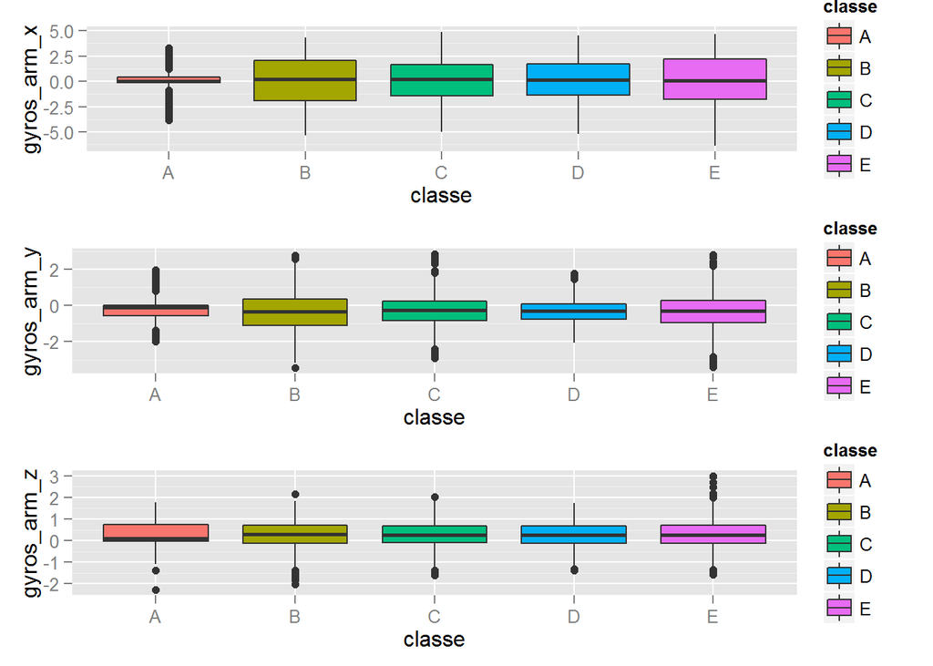

```r
library(ggplot2);library(gridExtra);
#plots on gyros - arms
p1 <- qplot(classe,gyros_arm_x,data=training, fill=classe,geom=c("boxplot"))
p2 <- qplot(classe,gyros_arm_y,data=training, fill=classe,geom=c("boxplot"))
p3 <- qplot(classe,gyros_arm_z,data=training, fill=classe,geom=c("boxplot"))
grid.arrange(p1,p2,p3)
```

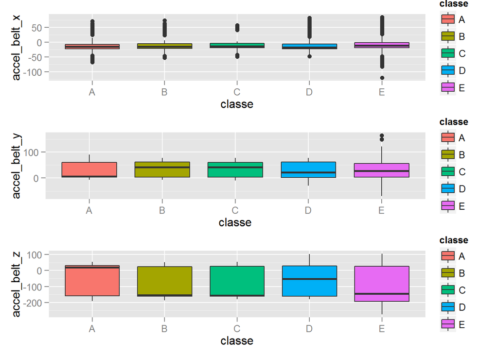

```r
#plots on accel - belt
p1 <- qplot(classe,accel_belt_x,data=training, fill=classe,geom=c("boxplot"))
p2 <- qplot(classe,accel_belt_y,data=training, fill=classe,geom=c("boxplot"))
p3 <- qplot(classe,accel_belt_z,data=training, fill=classe,geom=c("boxplot"))
grid.arrange(p1,p2,p3)
```

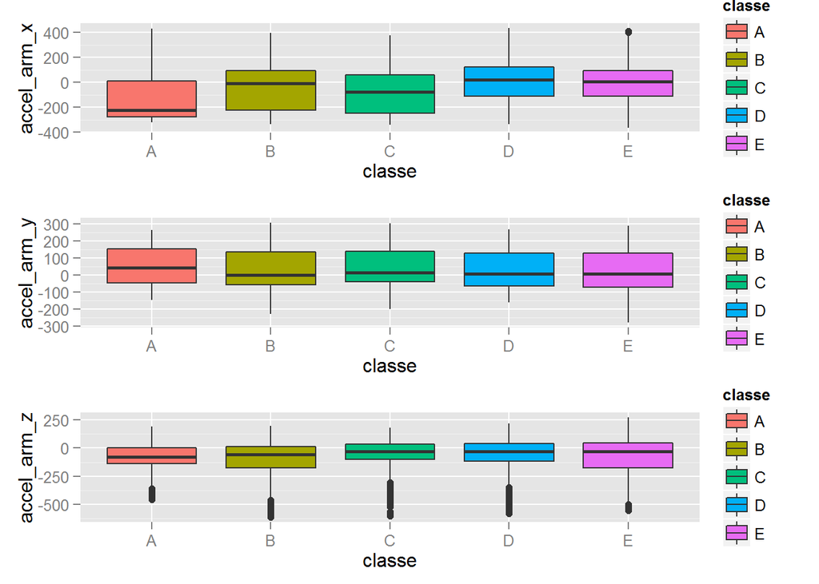

```r
#plots on accel - arm
p1 <- qplot(classe,accel_arm_x,data=training, fill=classe,geom=c("boxplot"))
p2 <- qplot(classe,accel_arm_y,data=training, fill=classe,geom=c("boxplot"))
p3 <- qplot(classe,accel_arm_z,data=training, fill=classe,geom=c("boxplot"))
grid.arrange(p1,p2,p3)
```